# chapter 18 The Bias-Variance Tradeoff

# 18–1 The Error of an Estimator

How good is an estimator overall? If $\hat\theta$ is an estimator for $\theta$, one way to quantify the *overall* discrepancy between $\hat\theta$ and $\theta$ is using a **loss function**, $L(\theta, \hat\theta)$. Two examples of loss functions:

$$L(\theta, \hat\theta) = | \hat\theta - \theta | \hspace{2cm} \text{absolute error loss}$$
$$L(\theta, \hat\theta) = ( \hat\theta - \theta )^2 \hspace{2cm} \text{squared error loss}$$

To assess an estimator we can compute the *average* loss, which we denote the **risk** of an estimator:

$$R(\theta,\hat\theta) = {\text{E}}\big[ L(\theta,\hat\theta) \big]$$

## The mean squared error

A common measure of an estimator’s overall quality is the mean quared error, MSE, defined:

$${\text{MSE}}(\hat\theta) = {\text{E}}\big[ (\hat\theta - \theta)^2 \big]$$

i.e. the MSE is the expected value of the estimator’s squared error loss—it’s a measure of the average squared distance between the estimator and the true value.

We know that bias and variance both contribute to the overall error of an estimator. By expanding the form given above, it’s possible to show that the MSE is a combination of both:

$$\begin{aligned}
{\text{MSE}}(\hat\theta) &= {\text{E}}\big[ (\hat\theta - \theta)^2 \big] \\
&= {\text{E}}\big[ (\hat\theta - {\text{E}}[\hat\theta] + {\text{E}}[\hat\theta] - \theta)^2] \\
&\; \; \vdots \\
&= {\text{E}}\big[(\hat\theta - {\text{E}}[\hat\theta])^2] + \big( {\text{E}}[\hat\theta]-\theta \big)^2 \\
&= {\text{Var}}[\hat\theta] + {\text{Bias}}[\hat\theta]^2
\end{aligned}$$

See the full proof of the Bias-Variance decomposition of MSE [here](https://en.wikipedia.org/wiki/Mean_squared_error#Proof_of_variance_and_bias_relationship).

i.e. the MSE can be expressed as the sum of the variance and squared bias of the estimator. If an estimator is unbiased, its MSE is simply equal to its variance.

## Trading between bias and variance

Note the difference between bias and variance:

$${\text{Var}}[\hat\theta] = {\text{E}}\big[ (\hat\theta - {\text{E}}[\hat\theta])^2 \big] \hspace{1cm} {\text{Bias}}[\hat\theta] = {\text{E}}[\hat\theta] - \theta$$

i.e. variance is a measure of the *spread* of an estimate (how closely the data points are clustered), and bias is a measure of how far the cluster actually is from the true value. Below is an illustration of different combinations of bias and variance:

Source: http://scott.fortmann-roe.com/docs/BiasVariance.html

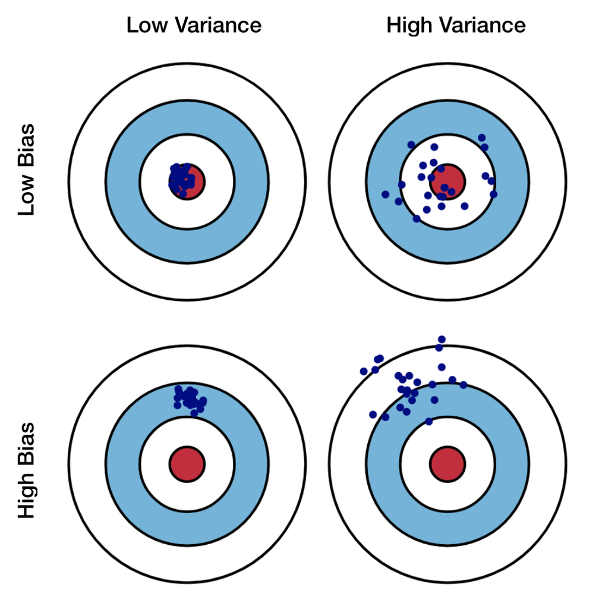

The *ideal* estimator would have low bias and low variance. It turns out though that it’s not always possible to minimize both—there are many cases where an estimator with low variance has high bias, and vice versa. You’ll come to see how sometimes it’s more optimal to introduce a little bias, as this can result in a better overall estimator.

Choosing the ideal estimator is part of **statistical decision theory**.

# 18–2 Normal Means and Stein’s Paradox

Suppose the parameters of interest are the mean of a multivariate normal $\theta = \mu = (\mu_1, ..., \mu_p)$.

Suppose $X$ is multivariate normal with mean $\mu$. Thus $E[X] = \mu$ is unbiased. What about MSE?

If $p=1$ or $p=2$, $X$ has the lowest MSE.

If $p \geq 3$ then $X$ no longer has the lowest MSE.

This is sometimes called Stein’s paradox after Charles Stein.

In high dimensions, it’s usually better to be biased.

If you find this very interesting there is a classic example about baseball you can read about. Summary: when estimating many players’ batting averages in the next season, instead of using each players’ average from this season as their own estimate it’s better to make all the estimates biased toward the overall average of the players.

```r
p = 100
JS <- function(x) max((1 - (p-2)/sum(x^2)),0) * x
mu = sample(c(1:5), p, replace = TRUE)
```

```r
SEs <- replicate(10000, sum(((rnorm(p) + mu) - mu)^2))
JSSEs <- replicate(10000, sum(((JS(rnorm(p) + mu)) - mu)^2))
mean(SEs)
```

```
## [1] 99.82492
```

```r
mean(JSSEs)
```

```
## [1] 92.20235
```